# Ggplot2之qplot散点图

#### 颜色、大小、形状和其它图形属性

> qplot与plot的差别在于，二者在给图中的点设定颜色、大小、形状等采用不同的实现方式。plot中，用户将数据中的一个分类变量转化为plot理解的形式（‘red’，‘yellow’）。而qplot能够自动完成。

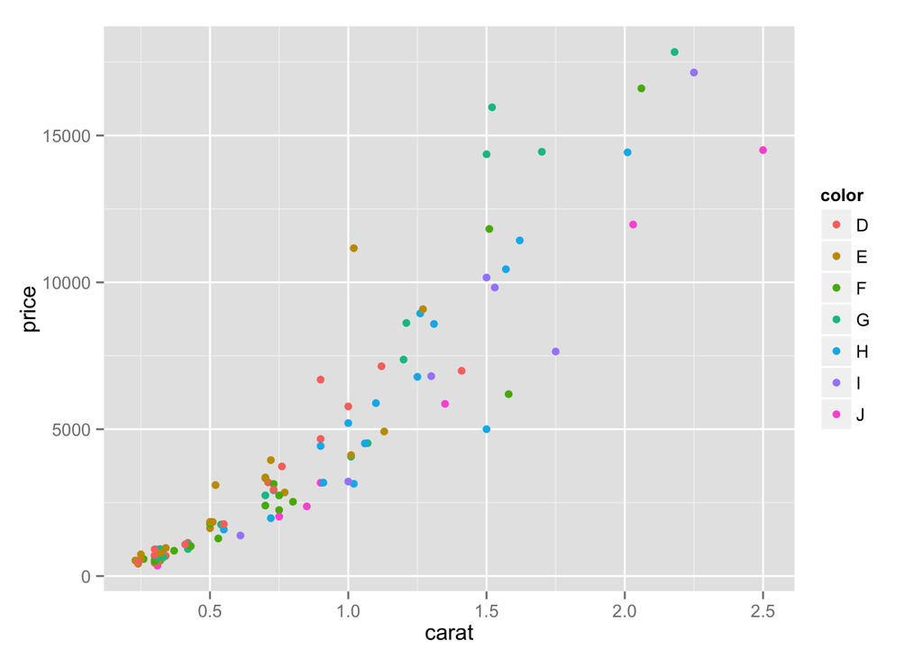

```r
#将重量和价格的散点图，添加颜色信息
qplot(carat,price,data=dsmall,colour=color)
```

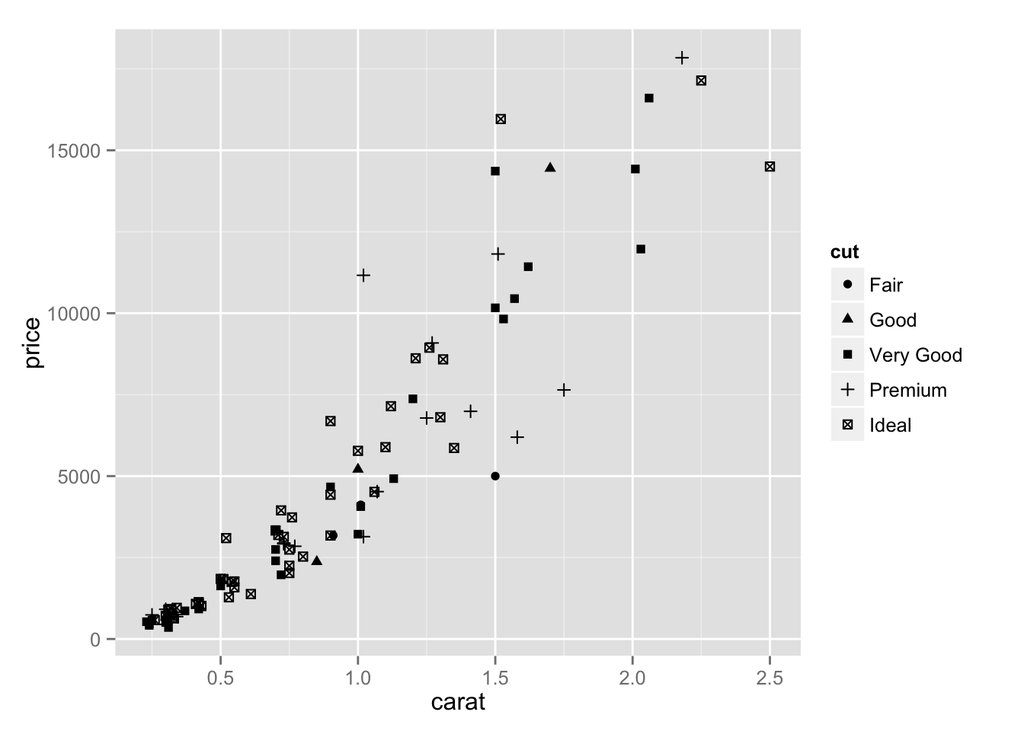

```r
#添加切工的信息
qplot(carat,price,data=dsmall,shape=cut)
```

> 可以使用I()来手动设定图形属性，比如colour=I(“red”),size=I(2)等。 比如alpha=I(1/20)中，分母表示经过多少次重叠之后颜色将变得不透明。不同的类型的变量适合不同的图形属性，比如颜色和形状适合于分类变量，大小适合于连续变量。如果数据量很大，一种可能的解决方案是分面。

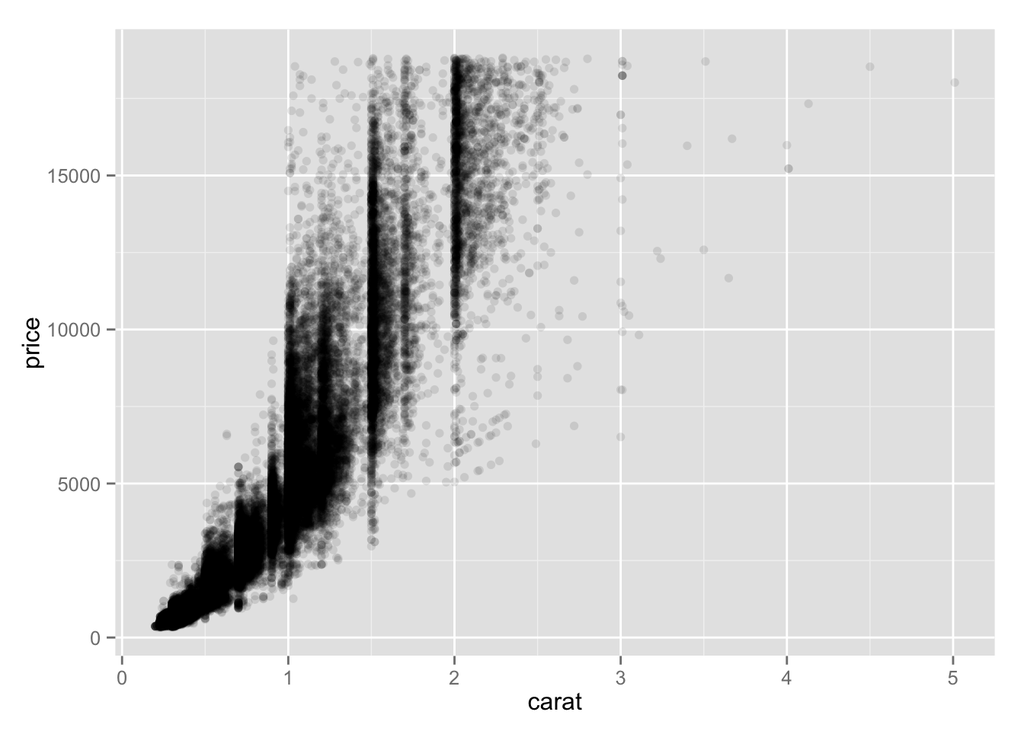

```r
qplot(carat,price,data=diamonds,alpha=I(1/10))
```

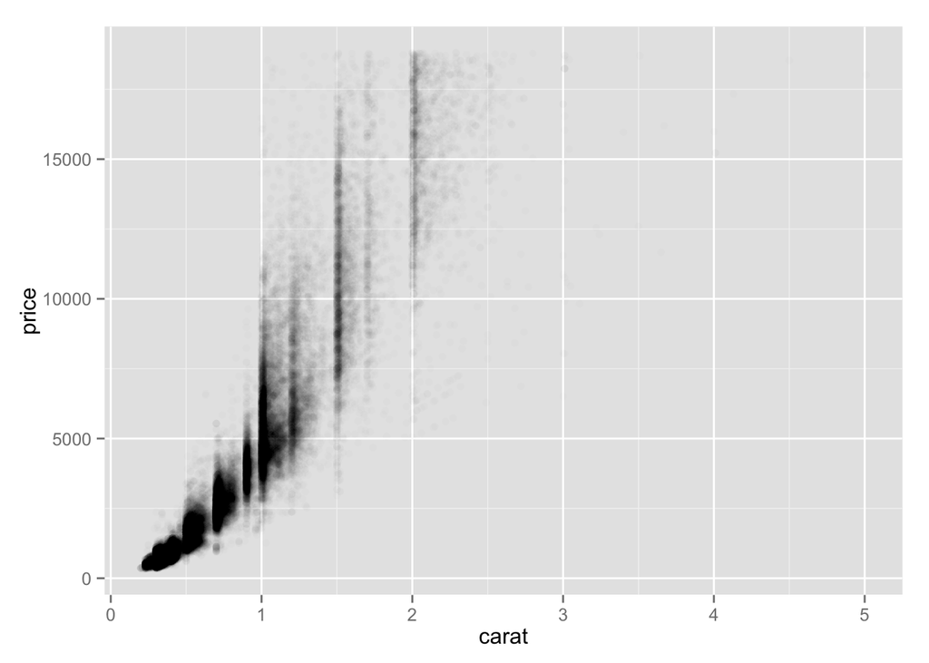

```r
qplot(carat,price,data=diamonds,alpha=I(1/100))
```

#### 几何对象的改变(geom)

> qplot也可以通过改变几何对象，画出任何一种类型的图形。有的几何对象对应了相应的统计变化（stats）。比如，直方图相当于分组计数统计变化和条形几何对象。

声明: 本文采用 [BY-NC-SA](http://creativecommons.org/licenses/by-nc-sa/3.0/) 授权。转载请注明转自: tegulia

« S3类介绍

Ggplot2线条图 »